### This will use the tidyverse package and the “gapminder” data set

```r
library(tidyverse)
library(gapminder)
data("gapminder")
df = gapminder
head(gapminder)
```

```
## # A tibble: 6 x 6
##   country     continent  year lifeExp      pop gdpPercap
##   <fct>       <fct>     <int>   <dbl>    <int>     <dbl>
## 1 Afghanistan Asia       1952    28.8  8425333      779.
## 2 Afghanistan Asia       1957    30.3  9240934      821.
## 3 Afghanistan Asia       1962    32.0 10267083      853.
## 4 Afghanistan Asia       1967    34.0 11537966      836.
## 5 Afghanistan Asia       1972    36.1 13079460      740.
## 6 Afghanistan Asia       1977    38.4 14880372      786.
```

## Exercise 1

```r
levels(df$continent)
```

```
## [1] "Africa"   "Americas" "Asia"     "Europe"   "Oceania"
```

**Add “Antarctica” to the levels of possible continents**

## Exercise 2

**Add 3 more continents to the factor levels: “North America”, “South America”, and “Central America”**

## Exercise 3

**Consider the following groupings of countries**

```r
south <- c("Argentina","Bolivia","Brazil","Chile","Colombia","Ecuador",
           "Paraguay","Peru","Uruguay","Venezuela")
north <- c("United States","Canada","Mexico")
central <- c("Costa Rica","El Salvador","Guatemala","Honduras","Nicaragua","Panama")
```

**Currently, they are all in the “Americas” continent group.** **Write some code to move them into their new respective continents**

## Exercise 4

**Clean up the “Continent” categories to remove “Americas” and “Antarctica”**

```r
levels(df$continent)
```

```
## [1] "Africa"   "Americas" "Asia"     "Europe"   "Oceania"
```

## Exercise 5

**Statistical models often use the FIRST level of a factor as a reference group** **Reorder the levels of the “Continent” factor so that “North America” will be the reference group**

## Exercise 6

Ordered Factors:

```r
status <- c("Lo", "Hi", "Med", "Med", "Hi","Lo", "Hi", "Med", "Med", "Hi")
status <- factor(status)
ordered.status <- factor(status, levels = c("Lo","Med","Hi"), ordered = TRUE)

table(status)
```

```
## status
##  Hi  Lo Med
##   4   2   4
```

```r
table(ordered.status)
```

```
## ordered.status
##  Lo Med  Hi
##   2   4   4
```

**Some functions in R treat ordered factors differently than unordered factors** **What is different about an ordered factor?**

## Exercise 7

```r
as.numeric(status) + 1
```

```
##  [1] 3 2 4 4 2 3 2 4 4 2
```

**Figure out what is going on with the expression above.**

## Exercise 8

```r
sub_status <- status[status %in% c("Lo","Hi")] # extract only the "Lo" and "Hi" values
sub_status
```

```
## [1] Lo Hi Hi Lo Hi Hi
## Levels: Hi Lo Med
```

**Re-factor “sub_status” to remove the “Med” level**

## Exercise 9

```r
status2 <- factor(c("Med", "Hi","Lo", "Hi", "Medium High"))
c(status,status2)
```

```
##  [1] 2 1 3 3 1 2 1 3 3 1 3 1 2 1 4
```

**Find a way to properly combine the two factored vectors “status” and “status2”** **Make sure the resulting vector is a factor as well**

## Exercise 10

Look at the following plot:

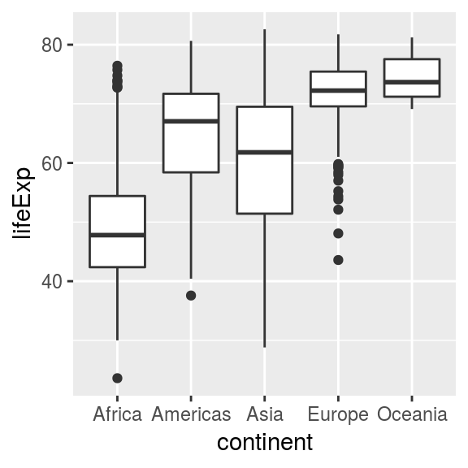

```r
ggplot(df,aes(x=continent,y=lifeExp)) + geom_boxplot()
```

**Re-make the plot so that the bars are in descending order**

## Exercise 11

#### If:

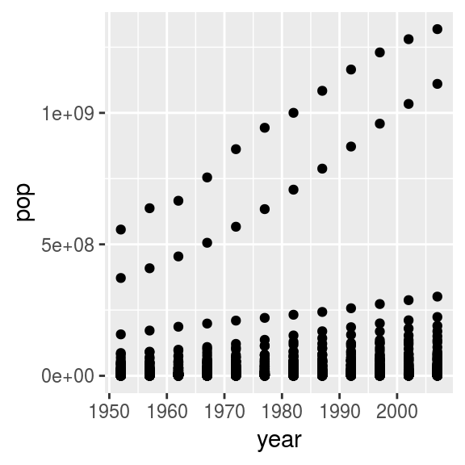

```r
ggplot(df, aes(x=year,y=pop)) + geom_point()
```

#### And …

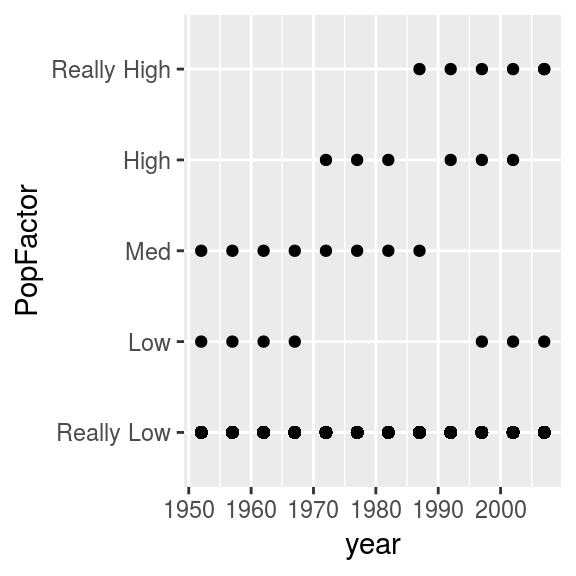

```r
df$PopFactor <- cut(df$pop,5,labels = c("Really Low","Low","Med","High","Really High"))
ggplot(df, aes(x=year,y=PopFactor)) + geom_point()
```

**Convert the gdpPercap to an ordered factor with 6 levels and plot it against year**